# Analysis_css

Annamaria_Culpo_228184

20/8/2022

# Decision trees

In order to analyze the variable importance of the predictors in the dataset, a regression decision tree is fitted using the abortion ratio as the response variable. At first, we load the library *tree* and we import the dataset.

```r
if(!require(tree)) {
    install.packages("tree")
    library(tree)
}
```

```r
options(scipen = 999)
df <- read.csv("final_df_procapite.csv", header=T)
head(df)
```

|  | geo | country | population | age_1_child | employed_women_2018 | abortion_ratio | social_benefit | mean_income | fertility_rate | lb_18y_procapite | lb_30y_procapite | lb_inmar_procapite | lb_outmar_procapite | lb_foreign_procapite |
| --- | --- | --- | --- | --- | --- | --- | --- | --- | --- | --- | --- | --- | --- | --- |
| 1 | AT | Austria | 8822267 | 29.5 | 0.686 | 20.9 | 993.78 | 27804 | 1.47 | 0.00003434491 | 0.0007025405 | 0.005694795 | 0.004000559 | 0.00290140845 |
| 2 | BE | Belgium | 11398589 | 29.0 | 0.607 | 154.4 | 717.46 | 25196 | 1.62 | 0.00003903992 | 0.0008946721 | 0.004946051 | 0.005434094 | 0.00256058009 |
| 3 | BG | Bulgaria | 7050034 | 26.2 | 0.630 | 376.8 | 113.35 | 4644 | 1.56 | 0.00022212659 | 0.0005670895 | 0.003663812 | 0.005158415 | 0.00005645363 |
| 4 | CH | Switzerland | 8484130 | 30.9 | 0.757 | 116.8 | 901.61 | 49607 | 1.52 | 0.00001426192 | 0.0007840521 | 0.007693776 | 0.002660968 | 0.00412758880 |
| 5 | CY | Cyprus | 864236 | 29.8 | 0.642 | 0.4 | 288.41 | 17582 | 1.32 | 0.00005091202 | 0.0008597189 | 0.008767281 | 0.002027224 | 0.00335556492 |
| 6 | CZ | Czech Republic | 10610055 | 28.4 | 0.676 | 160.5 | 295.16 | 10098 | 1.71 | 0.00006559815 | 0.0008368477 | 0.005532299 | 0.005215619 | 0.00068548184 |

We rearrange the columns of the dataframe in order to have the response variable on the right end side, so it will be easier to fit the models.

```r
col_order <- c("geo", "country", "population", "age_1_child", "employed_women_2018", "social_benefit", "mean_income", "fertility_rate", "lb_18y_procapite", "lb_30y_procapite", "lb_inmar_procapite", "lb_outmar_procapite", "lb_foreign_procapite", "abortion_ratio")

df_ord <- df[, col_order]
```

We fit a regression tree and we produce a summary of the resulting model.

```r
set.seed(2)
tree_df <- tree(abortion_ratio ~ age_1_child + employed_women_2018 + social_benefit +
                  mean_income + fertility_rate + lb_18y_procapite + lb_30y_procapite +
                  lb_inmar_procapite + lb_outmar_procapite + lb_foreign_procapite, df_ord)
summary(tree_df)
```

```
##
## Regression tree:
## tree(formula = abortion_ratio ~ age_1_child + employed_women_2018 +
##     social_benefit + mean_income + fertility_rate + lb_18y_procapite +
##     lb_30y_procapite + lb_inmar_procapite + lb_outmar_procapite +
##     lb_foreign_procapite, data = df_ord)
## Variables actually used in tree construction:
## [1] "lb_inmar_procapite"   "age_1_child"          "lb_foreign_procapite"
## [4] "lb_30y_procapite"
## Number of terminal nodes:  6
## Residual mean deviance:  3378 = 94580 / 28
## Distribution of residuals:
##    Min. 1st Qu.  Median    Mean 3rd Qu.    Max.
## -129.30  -37.21   -4.48    0.00   35.93  100.50
```

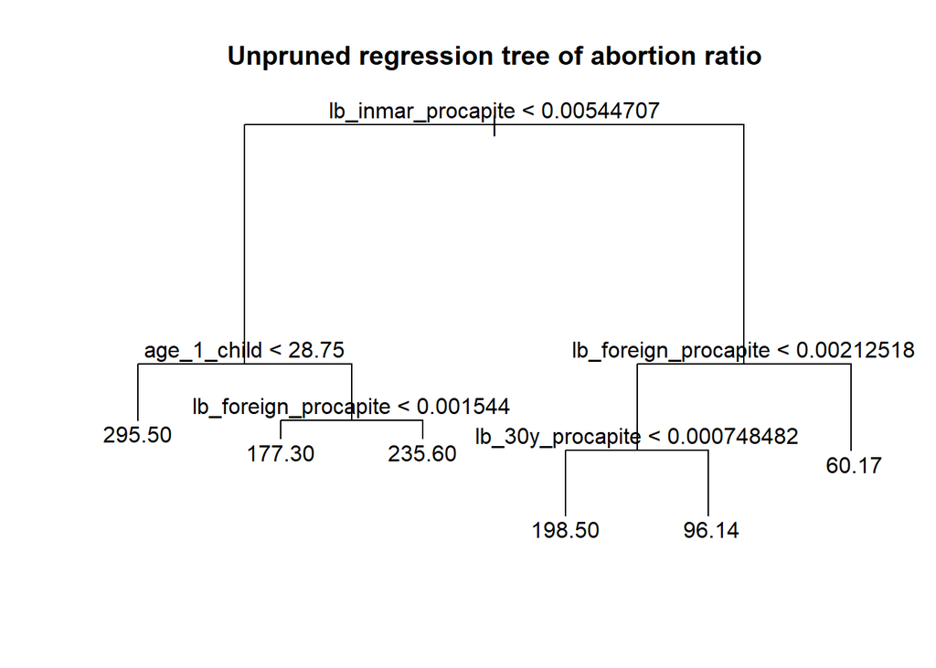

```r
plot(tree_df)
text(tree_df, pretty=0)
title(main="Unpruned regression tree of abortion ratio")
```

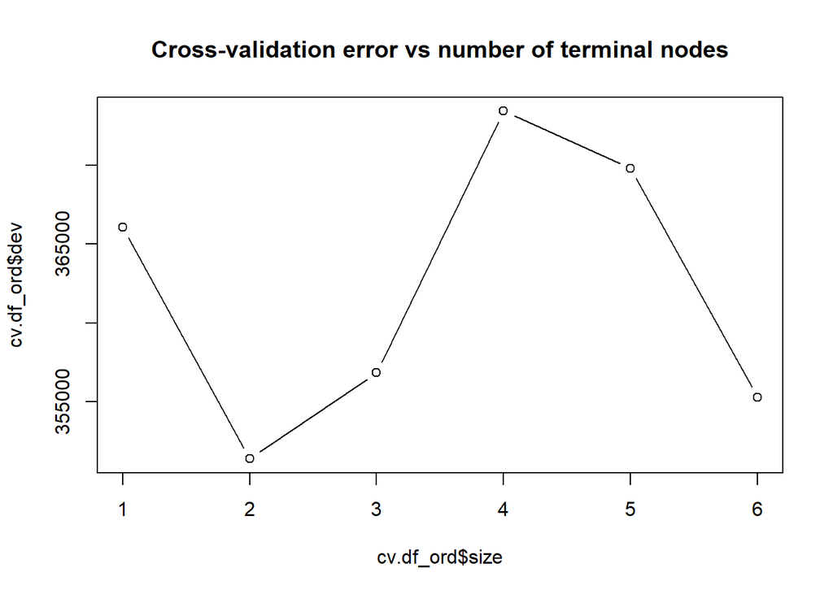

```r
cv.df_ord <- cv.tree(tree_df)
plot(cv.df_ord$size, cv.df_ord$dev, type="b")
title(main="Cross-validation error vs number of terminal nodes")
```

```r
cv.df_ord
```

```
## $size
## [1] 6 5 4 3 2 1
##
## $dev
## [1] 355274.0 369815.7 373434.0 356822.5 351377.1 366081.5
##
## $k
## [1]       -Inf   8485.569  26456.760  30559.578  40472.036 111874.325
##
## $method
## [1] "deviance"
##
## attr(,"class")
## [1] "prune"         "tree.sequence"
```

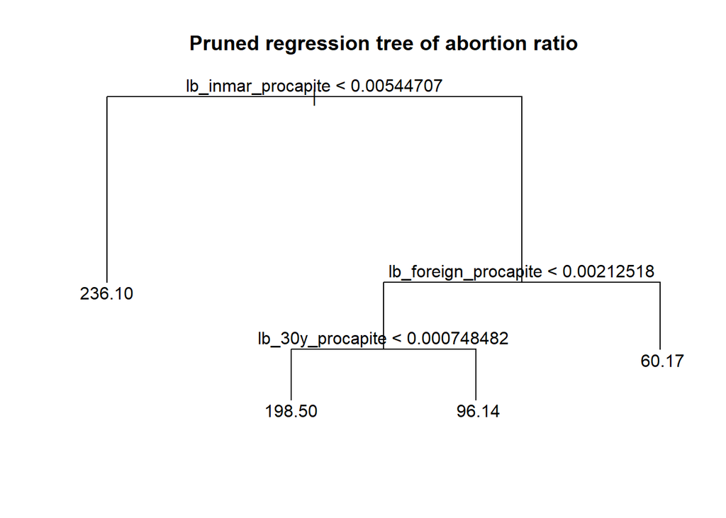

```r
prune_df_ord <- prune.tree(tree_df, best=4)
plot(prune_df_ord)
text(prune_df_ord, pretty=0)
title(main="Pruned regression tree of abortion ratio")
```

```r
summary(prune_df_ord)
```

```
##
## Regression tree:
## snip.tree(tree = tree_df, nodes = 2L)
## Variables actually used in tree construction:
## [1] "lb_inmar_procapite"   "lb_foreign_procapite" "lb_30y_procapite"
## Number of terminal nodes:  4
## Residual mean deviance:  4317 = 129500 / 30
## Distribution of residuals:
##     Min.  1st Qu.   Median     Mean  3rd Qu.     Max.
## -129.300  -54.600   -7.663    0.000   55.490  140.700
```

As happened for the unpruned tree, also the pruned one shows the number of live births inside marriage per inhabitant as the stump of the tree, with the same cutpoint as before. But in this case, if the value of this variable is lower than 0.00545, the predicted abortion ratio of the country is about 236 abortion per 1000 live births. The other variables that have stayed in the tree are the number of live births from foreign women and the number of live births from 30-yers-old mothers, both values referred to every inhabitant.

# Random forest

A more efficient non-linear method based on several decision trees is random forest. To select the best number of predictors to pick at each split, a cross-validation function could be used. The function rfcv() of the randomForest package performs a k-fold cross-validation to select the best number m of predictors to pick at each split of a tree. The best m is the one associated to the lowest cross-validation error. The number of folds has been set as k=10. The step = 0.9 allows to decrease the number of predictors of 1 variable at a time. The rfcv() function outputs the number of predictors at each iteration (*n.var*), the cross-validation error (*error.cv*) and the predictions of the response variable (*predicted*) for every m. Then, the parameter mtry associated to the lowest cv error can be used to fit a random forest model on the data.

```r
library(randomForest)
set.seed(2)
nvar = 10 #number of all predictors
(cv_randomforest <- rfcv(trainx = df_ord[,4:13], trainy = df_ord[,14], cv.fold = 10, scale = "log", step = 0.9 ))
```

```
## $n.var
##  [1] 10  9  8  7  6  5  4  3  2  1
##
## $error.cv
##       10        9        8        7        6        5        4        3
## 5909.237 6227.215 6183.477 5961.999 6038.197 6159.457 6384.313 6785.912
##        2        1
## 7617.355 8840.269
##
## $predicted
## $predicted$`10`
##  [1] 153.19076 208.76547 199.69110  91.79085  86.35832 215.91609 138.57361
##  [8] 227.97954 231.88423 123.98761 164.54247 158.08038 231.12048 121.46653
## [15] 173.24285 117.11974 252.35584 199.66233 119.08173 125.85058 163.12067
## [22] 106.92969 143.15011 205.35774 204.10401 140.66137 193.05763 169.01965
## [29] 147.61239 234.88561 216.58501 169.89206 159.96947 187.32916
##
## $predicted$`9`
##  [1] 166.3403 211.2500 195.7372  77.2944  87.0901 224.1104 138.5537 228.4355
##  [9] 233.2669 120.8951 168.3857 161.2686 220.9842 114.5336 180.0641 115.4063
## [17] 261.6785 201.5434 125.1877 138.6977 162.8594 104.2724 139.0467 211.8423
## [25] 205.5044 143.1942 202.3121 162.6539 147.1691 233.3091 227.4762 173.4640
## [33] 158.3081 184.8980
##
## $predicted$`8`
##  [1] 164.68464 209.81997 202.64899  94.13653  90.59319 215.69256 150.77729
##  [8] 218.86715 231.30646 133.48775 168.84451 157.62446 208.58610 120.27281
## [15] 172.50097 119.35528 256.54879 202.20431 127.57613 139.48262 159.05489
## [22]  97.02471 135.15334 213.19508 199.86014 138.32219 200.91937 157.82027
## [29] 151.96483 229.32760 221.09752 178.53167 160.15194 188.47949
##
## $predicted$`7`
##  [1] 154.93811 215.99012 199.91980  93.20788  85.19376 202.54418 143.41041
##  [8] 232.57674 226.78091 137.47076 170.62457 172.84992 221.57839 126.75655
## [15] 169.74683 124.75181 262.82013 203.22807 109.76853 134.51917 164.38711
## [22] 100.84320 129.88126 219.94128 199.93513 144.86903 209.84598 161.03640
## [29] 152.06295 234.54386 228.41902 154.53391 147.27821 184.16479
##
## $predicted$`6`
##  [1] 155.95699 212.42948 201.14845  71.16878  80.02778 202.87996 133.22725
```

[output cut: 24 more lines]

```
## [29] 120.46112 255.72242 229.14579 190.78367 110.14550 169.80539
##
## $predicted$`2`
##  [1] 200.65253 219.18531 183.12617  86.25322  94.03554 189.22868 148.26620
##  [8] 235.77272 232.89947  94.87290 186.35649 205.44025 244.40133  80.60428
## [15] 156.91658 119.39246 304.77941 180.90389  93.82885 177.75035 121.01337
## [22]  94.25886 120.36123 229.98330 260.31093 168.24607 244.68905 113.89488
## [29]  89.57243 252.12616 233.84077 126.43792  94.25886 180.39583
##
## $predicted$`1`
##  [1] 198.46947 210.59079 144.87079 112.28948 110.96140 179.05869 133.10262
##  [8] 253.23894 180.43831 170.51130 168.34265 198.74781 268.56883 170.51130
## [15] 131.91388 173.60128 315.03542 202.37518 100.03777 142.87432 198.53297
## [22]  36.31130  69.12305 272.24042 241.48502 216.88556 145.66610 157.03358
## [29]  79.46529 253.99385 221.08230 102.80590  36.31130 173.83682
```

```r
cv_rf_error <- cv_randomforest$error.cv
min_cv_index <- as.integer(names(which(cv_rf_error == min(cv_rf_error)[1])))
```

The number of parameters to pick at each split associated to the minimum cross validation error is 10, as we can see also from the following plot.

[figure not shown]

```r
plot(c(1:10), rev(cv_rf_error), type="b", col="red", lwd=1.5,
     xlim = c(0,11), ylim = c(7400,9500),
     xlab = "Number of predictors m",
     ylab = "Cv error rate")
title(main = "CV error as a function of the number of predictors")
```

```r
best_rf_model <- randomForest(abortion_ratio ~ age_1_child + employed_women_2018 + social_benefit +
                  mean_income + fertility_rate + lb_18y_procapite + lb_30y_procapite +
                  lb_inmar_procapite + lb_outmar_procapite + lb_foreign_procapite,
                  data = df_ord, mtry = min_cv_index, importance=TRUE)
best_rf_model
```

```
##
## Call:
##  randomForest(formula = abortion_ratio ~ age_1_child + employed_women_2018 +      social_benefit + mean_income + fertility_rate + lb_18y_procapite +      lb_30y_procapite + lb_inmar_procapite + lb_outmar_procapite +      lb_foreign_procapite, data = df_ord, mtry = min_cv_index,      importance = …
##                Type of random forest: regression
##                      Number of trees: 500
## No. of variables tried at each split: 10
##
##           Mean of squared residuals: 7040.542
##                     % Var explained: 23.38
```

Random forest allows to check the importance of every predictor with respect to the response variable.

```r
knitr::kable(importance(best_rf_model))
```

|  | %IncMSE | IncNodePurity |
| --- | --- | --- |
| age_1_child | -1.3374714 | 10757.355 |
| employed_women_2018 | 0.8645343 | 15426.238 |
| social_benefit | 0.0821189 | 8099.036 |
| mean_income | 3.7022888 | 10212.958 |
| fertility_rate | 1.7142288 | 22773.804 |
| lb_18y_procapite | 2.0640592 | 19268.123 |
| lb_30y_procapite | 6.0037702 | 17325.338 |
| lb_inmar_procapite | 12.6034422 | 88283.005 |
| lb_outmar_procapite | 9.8714652 | 53875.613 |
| lb_foreign_procapite | 5.7519708 | 46610.797 |

The second column of the table measures the increment of the node purity that results from splits over that variable. As in the previous case, the greatest increase of the purity is associated to the live births per capita inside and outside marriage, while the lowest value is referred to the social benefits per inhabitant provided by the government.

A visual representation of what has been explained above could be rendered by the following plot.

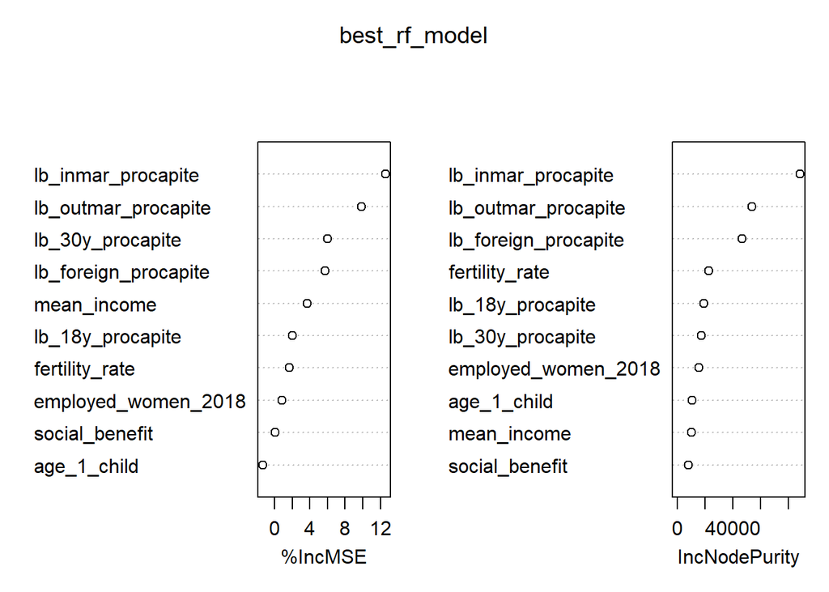

```r
varImpPlot(best_rf_model)
```

# Lasso and ridge

Since the predictors have different value ranges, standardizing them before applying Lasso and Ridge regression could be useful in order to have coefficients with a comparable magnitude. So we center every variable at zero and we standardize its variance at 1.

```r
library(dplyr)
set.seed(123)
df_scaled <- df_ord %>% mutate_at(c("age_1_child", "employed_women_2018", "social_benefit", "mean_income", "fertility_rate", "lb_18y_procapite", "lb_30y_procapite", "lb_inmar_procapite", "lb_outmar_procapite", "lb_foreign_procapite", "abortion_ratio"), ~(scale(.) %>% as.vector))
```

## Ridge

```r
library(tidyverse)
library(ISLR2)
library(glmnet)
```

```r
#Ridge (alpha=0)
x <- df_scaled[,4:13]
y <- df_scaled[,14]
ridge_mod <- glmnet(x, y, alpha=0, standardize = FALSE) #standardize=FALSE because the df is already scaled
dim(coef(ridge_mod))
```

```
## [1]  11 100
```

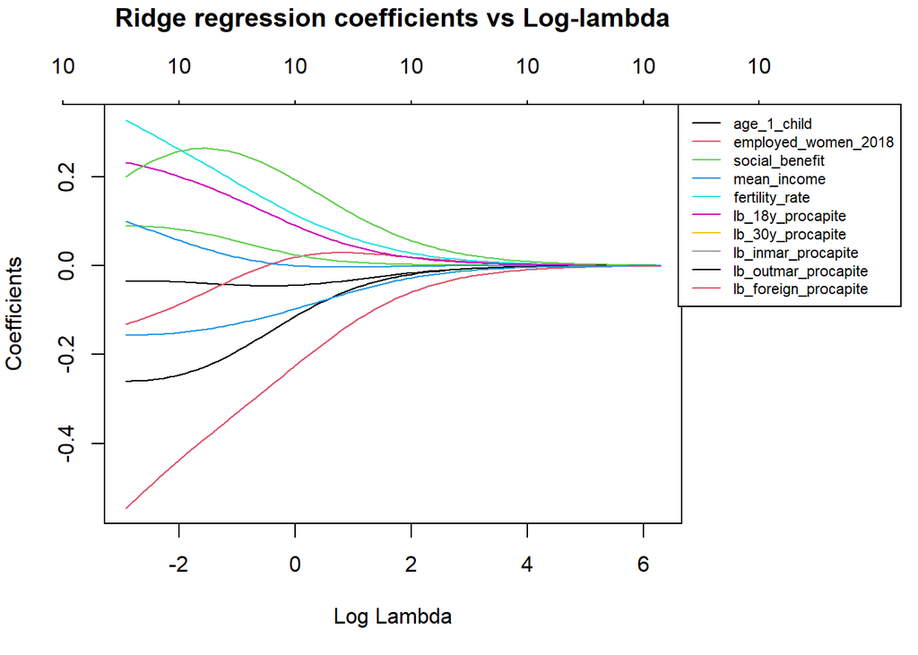

```r
par(mar=c(5, 4, 4, 9), xpd=TRUE)
plot(ridge_mod, xvar="lambda") # coefficients vs log lambda
legend("topright", lwd = 1, col = 1 : 10, legend = colnames(x), cex = .7, inset = c(-0.38,0))
title(main="Ridge regression coefficients vs Log-lambda", line = 3)
```

100 different values of lambda have been applied to the 10 predictors (plus the intercept), generating a corresponding number of ridge regression models. In the plot above it can be seen that as long as the value of lambda increases, the coefficients are shrunk towards zero, even if they are never completely zeroed. When lambda is equal to zero, on the very left side of the plot, the coefficients are equal to the ones of a linear regression.

The parameter lambda controls the bias-variance trade-off: when lambda increases, the variance goes down, but the bias augments. In order to find the optimal value of lambda that allows a sort of compromise, we can use cross-validation. In this specific case, we are going to divide the dataset into train and test sets and we perform a 10-fold-cross-validation on the training set.

```r
set.seed(2)
x <- model.matrix(abortion_ratio ~ age_1_child + employed_women_2018 + social_benefit +
                  mean_income + fertility_rate + lb_18y_procapite + lb_30y_procapite +
                  lb_inmar_procapite + lb_outmar_procapite + lb_foreign_procapite, df_scaled[,4:14])
y <- df_scaled[,14]
```

```r
set.seed(2)
train <- sample(1:nrow(x), nrow(x)/2)
test <- -train # numerical indexes, so we complement with -
y_test <- y[test]

x_train <- x[train, ]
x_test <- x[test, ]
y_train <- y[train]
```

```r
set.seed(2)
cv_ridge <- cv.glmnet(x_train, y_train, alpha = 0, lambda = ridge_mod$lambda)
best_lambda <- cv_ridge$lambda.min
best_lambda
```

```
## [1] 0.0594494
```

Now we can examine the coefficient estimates corresponding to the value of lambda having the minimum cross-validation error.

```r
predict(ridge_mod, type="coefficients", s=best_lambda)
```

```
## 11 x 1 sparse Matrix of class "dgCMatrix"
##                                             s1
## (Intercept)           0.0000000000000001233705
## age_1_child          -0.0349345777500948001526
## employed_women_2018  -0.1278550941903477400352
## social_benefit        0.0886267539427801481766
## mean_income           0.0951185527221329596426
## fertility_rate        0.3201487146316807641533
## lb_18y_procapite      0.2294967729832157465886
## lb_30y_procapite     -0.2597745017478148010781
## lb_inmar_procapite   -0.5337971650781960786247
## lb_outmar_procapite   0.2079770640432389572361
## lb_foreign_procapite -0.1556868439693369077226
```

The coefficients with negative values imply that an increase of their referring variable leads to a decrease of the abortion ratio, keeping all the other elements fixed. This happens for: - The age of the mother at her firstborn. If in a country women tend to become mothers when they are not too young, the number of abortions is lower - The number of live births per inhabitant from mothers aged 30. This coefficient is one of the greatest, considering the absolute value. A woman in her 30s has probably a job or at least an economic and sentimental condition which is rather stable. Hence, she could be more stimulated to have a child. The opposite situation could regard a woman aged 18, who has just finished her course of study and she may not have enough resources to grow a child. In fact, the coefficient of this variable is positive, meaning that an increase of the number of live births from 18-years-old women in a country leads to a higher abortion ratio. - The number of live births per inhabitant from married women. This is also the coefficient with the highest absolute value, so its variable has the major effect in predicting the abortion ratio of a country. Marriage is a social institution which guarantees several rights to their members and to the offspring; rights that are often not available for unmarried partners. This could be one of the reasons that justify the negative coefficient of the in-marriage live births and the positive one of the out-marriage live births. - The number of live births from foreign women has a negative value, so the increase of the variable results in a decrease of the abortion ratio.

Note that no coefficient is exactly equal to zero, because ridge regression shrinks all the coefficients towards zero, without completely eliminate them.

Now we can evaluate the Mean Squared Error of the ridge regression model (MSE) on the test set, using the best lambda found above.

```r
ridge_mod_train <- glmnet(x_train, y_train, alpha=0, standardize = FALSE)
ridge_pred <- predict(ridge_mod_train, s=best_lambda, newx=x_test)
(mse_test_ridge <- mean((ridge_pred - y_test)^2))
```

```
## [1] 1.507034
```

## Lasso

We repeat the procedure adopted for the ridge regression also for the lasso. The main difference between the two shrinkage methods is the possibility for the lasso to perform variable selection. In fact, unlike ridge, lasso coefficients can be set to zero for lambdas sufficiently large.

```r
lasso_mod <- glmnet(x_train, y_train, alpha = 1, standardize = FALSE)
dim(coef(lasso_mod))
```

```
## [1] 12 72
```

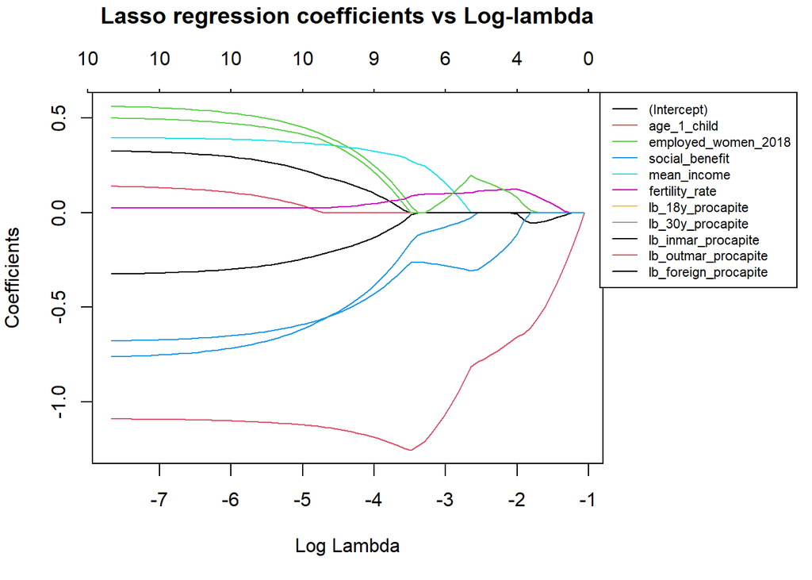

```r
par(mar=c(5, 4, 4, 9), xpd=TRUE)
plot(lasso_mod, xvar = "lambda")
legend("topright", lwd = 1, col = 1 : 10, legend = colnames(x), cex = .7, inset = c(-0.38,0))
title(main="Lasso regression coefficients vs Log-lambda", line = 3)
```

At a first glance, the plot of the lasso coefficients could seem similar to the one of the ridge. However, in this case some coefficients are set to zero in correspondence of increasing lambda values. It is visible also on the horizontal axis on the top of the graph, which shows the number of coefficients that are greater than zero. While in the ridge plot this axis has always values equal to ten (total number of the predictors), in the lasso graph the values decrease along with the rise of lambda.

Now we perform cross-validation to find the lambda associated to the least training mean squared error.

```r
set.seed(2)
cv_lasso <- cv.glmnet(x_train, y_train, alpha = 1, lambda = lasso_mod$lambda)
best_lambda_lasso <- cv_lasso$lambda.min
best_lambda_lasso
```

```
## [1] 0.05363423
```

We use the best lambda to fit a lasso regression on the full dataset and we analyze the coefficients.

```r
lasso_mod_full <- glmnet(x, y, alpha=1, standardize = FALSE)
# display coefficients using lambda chosen by CV
predict(lasso_mod_full, type="coefficients", s=best_lambda_lasso)
```

```
## 12 x 1 sparse Matrix of class "dgCMatrix"
##                                             s1
## (Intercept)           0.0000000000000001608585
## (Intercept)           .
## age_1_child           .
## employed_women_2018   .
## social_benefit        .
## mean_income           .
## fertility_rate        0.3701560132881454023845
## lb_18y_procapite      0.2241659356052085050326
## lb_30y_procapite     -0.1626581174982059951883
## lb_inmar_procapite   -0.6404239892413365886625
## lb_outmar_procapite   .
## lb_foreign_procapite -0.0201810139056204651542
```

Finally we can calculate the Mean Squared Error on the test set, so that we can compare it with the one of the ridge regression model.

```r
lasso_pred <- predict(lasso_mod, s=best_lambda_lasso, newx=x_test)
mse_test_lasso <- mean((lasso_pred - y_test)^2)
m <- matrix(c(mse_test_ridge, mse_test_lasso), ncol = 2)
colnames(m) <- c("MSE Ridge", "MSE Lasso")
mse <- as_tibble(m)
mse
```

| MSE Ridge | MSE Lasso |
| --- | --- |
| 1.507034 | 1.122108 |